# MNIST Handwritten Digit Recognition in PyTorch

## Reference: [MNIST Handwritten Digit Recognition in PyTorch](https://nextjournal.com/gkoehler/pytorch-mnist)

MNIST contains 70,000 images of handwritten digits: 60,000 for training and 10,000 for testing. The images are grayscale, 28x28 pixels, and centered to reduce preprocessing and get started quicker.

```python
import torch
import torchvision
```

# Preparing the Dataset

With the imports in place we can go ahead and prepare the data we'll be using. But before that we'll define the hyperparameters we'll be using for the experiment. Here the number of epochs defines how many times we'll loop over the complete training dataset, while `learning_rate` and `momentum` are hyperparameters for the optimizer we'll be using later on.

```python
n_epochs = 5
batch_size_train = 64
batch_size_test = 1000
learning_rate = 0.001
momentum = 0.5
log_interval = 10

random_seed = 1
torch.backends.cudnn.enabled = False
torch.manual_seed(random_seed)
```

```
<torch._C.Generator at 0x1fe715fe050>
```

For repeatable experiments we have to set random seeds for anything using random number generation - this means `numpy` and `random` as well! It's also worth mentioning that cuDNN uses nondeterministic algorithms which can be disabled setting `torch.backends.cudnn.enabled = False`.

Now we'll also need DataLoaders for the dataset. This is where TorchVision comes into play. It let's use load the MNIST dataset in a handy way. We'll use a `batch_size` of 64 for training and size 1000 for testing on this dataset. The values `0.1307` and `0.3081` used for the `Normalize()` transformation below are the global mean and standard deviation of the MNIST dataset, we'll take them as a given here.

TorchVision offers a lot of handy transformations, such as cropping or normalization.

```python
train_loader = torch.utils.data.DataLoader(
  torchvision.datasets.MNIST('/files/', train=True, download=True,
                             transform=torchvision.transforms.Compose([
                               torchvision.transforms.ToTensor(),
                               torchvision.transforms.Normalize(
                                 (0.1307,), (0.3081,))
                             ])),
  batch_size=batch_size_train, shuffle=True)

test_loader = torch.utils.data.DataLoader(
  torchvision.datasets.MNIST('/files/', train=False, download=True,
                             transform=torchvision.transforms.Compose([
                               torchvision.transforms.ToTensor(),
                               torchvision.transforms.Normalize(
                                 (0.1307,), (0.3081,))
                             ])),
  batch_size=batch_size_test, shuffle=True)
```

PyTorch's `DataLoader` contain a few interesting options other than the dataset and batch size. For example we could use `num_workers > 1` to use subprocesses to asynchronously load data or using pinned RAM (via `pin_memory`) to speed up RAM to GPU transfers. But since these mostly matter when we're using a GPU we can omit them here.

Now let's take a look at some examples. We'll use the `test_loader` for this.

```python
examples = enumerate(test_loader)
batch_idx, (example_data, example_targets) = next(examples)
```

Ok let's see what one test data batch consists of.

```python
example_data.shape
```

```
torch.Size([1000, 1, 28, 28])
```

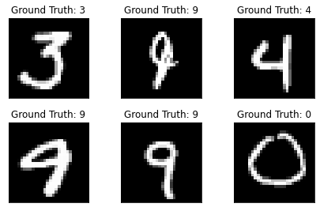

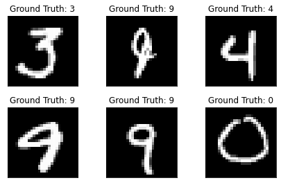

```python
import matplotlib.pyplot as plt

fig = plt.figure()
for i in range(6):
  plt.subplot(2,3,i+1)
  plt.tight_layout()
  plt.imshow(example_data[i][0], cmap='gray', interpolation='none')
  plt.title("Ground Truth: {}".format(example_targets[i]))
  plt.xticks([])
  plt.yticks([])
fig
```

# Building the Network

Now let's go ahead and build our network. We'll use two 2-D convolutional layers followed by two fully-connected (or *linear)* layers. As activation function we'll choose rectified linear units) (ReLUs in short) and as a means of regularization we'll use two dropout layers. In PyTorch a nice way to build a network is by creating a new class for the network we wish to build. Let's import a few submodules here for more readable code.

```python
import torch.nn as nn
import torch.nn.functional as F
import torch.optim as optim
```

```python
class Net(nn.Module):
    def __init__(self):
        super(Net, self).__init__()
        self.conv1 = nn.Conv2d(1, 10, kernel_size=5)
        self.conv2 = nn.Conv2d(10, 20, kernel_size=5)
        self.conv2_drop = nn.Dropout2d()
        self.fc1 = nn.Linear(320, 50)
        self.fc2 = nn.Linear(50, 10)

    def forward(self, x):
        x = F.relu(F.max_pool2d(self.conv1(x), 2))
        x = F.relu(F.max_pool2d(self.conv2_drop(self.conv2(x)), 2))
        x = x.view(-1, 320)
        x = F.relu(self.fc1(x))
        x = F.dropout(x, training=self.training)
        x = self.fc2(x)
        return F.log_softmax(x)
```

Broadly speaking we can think of the `torch.nn` layers as which contain trainable parameters while `torch.nn.functional` are purely functional. The `forward()` pass defines the way we compute our output using the given layers and functions. It would be perfectly fine to print out tensors somewhere in the forward pass for easier debugging. This comes in handy when experimenting with more complex models. Note that the forward pass could make use of e.g. a member variable or even the data itself to determine the execution path - and it can also make use of multiple arguments!

Now let's initialize the network and the optimizer.

```python
network = Net()
optimizer = optim.SGD(network.parameters(), lr=learning_rate,
                      momentum=momentum)
```

Note: If we were using a GPU for training, we should have also sent the network parameters to the GPU using e.g. `network.cuda()`. It is important to transfer the network's parameters to the appropriate device before passing them to the optimizer, otherwise the optimizer will not be able to keep track of them in the right way.

# Training the Model

Time to build our training loop. First we want to make sure our network is in training mode. Then we iterate over all training data once per epoch. Loading the individual batches is handled by the DataLoader. First we need to manually set the gradients to zero using `optimizer.zero_grad()` since PyTorch by default accumulates gradients. We then produce the output of our network (forward pass) and compute a negative log-likelihodd loss between the output and the ground truth label. The `backward()` call we now collect a new set of gradients which we propagate back into each of the network's parameters using `optimizer.step()`. For more detailed information about the inner workings of PyTorch's automatic gradient system, see [the official docs for autograd](https://pytorch.org/docs/stable/notes/autograd.html#) (highly recommended).

We'll also keep track of the progress with some printouts. In order to create a nice training curve later on we also create two lists for saving training and testing losses. On the x-axis we want to display the number of training examples the network has seen during training.

```python
train_losses = []
train_counter = []
test_losses = []
test_counter = [i*len(train_loader.dataset) for i in range(n_epochs + 1)]
```

We'll run our test loop once before even starting the training to see what accuracy/loss we achieve just with randomly initialized network parameters. Can you guess what our accuracy might look like for this case?

```python
def train(epoch):
  network.train()
  for batch_idx, (data, target) in enumerate(train_loader):
    optimizer.zero_grad()
    output = network(data)
    loss = F.nll_loss(output, target)
    loss.backward()
    optimizer.step()
    if batch_idx % log_interval == 0:
      print('Train Epoch: {} [{}/{} ({:.0f}%)]\tLoss: {:.6f}'.format(
        epoch, batch_idx * len(data), len(train_loader.dataset),
        100. * batch_idx / len(train_loader), loss.item()))
      train_losses.append(loss.item())
      train_counter.append(
        (batch_idx*64) + ((epoch-1)*len(train_loader.dataset)))
      torch.save(network.state_dict(), './results/model.pth')
      torch.save(optimizer.state_dict(), './results/optimizer.pth')
```

Neural network modules as well as optimizers have the ability to save and load their internal state using `.state_dict()`. With this we can continue training from previously saved state dicts if needed - we'd just need to call `.load_state_dict(state_dict)`.

Now for our test loop. Here we sum up the test loss and keep track of correctly classified digits to compute the accuracy of the network.

```python
def test():
  network.eval()
  test_loss = 0
  correct = 0
  with torch.no_grad():
    for data, target in test_loader:
      output = network(data)
      test_loss += F.nll_loss(output, target, size_average=False).item()
      pred = output.data.max(1, keepdim=True)[1]
      correct += pred.eq(target.data.view_as(pred)).sum()
  test_loss /= len(test_loader.dataset)
  test_losses.append(test_loss)
  print('\nTest set: Avg. loss: {:.4f}, Accuracy: {}/{} ({:.0f}%)\n'.format(
    test_loss, correct, len(test_loader.dataset),
    100. * correct / len(test_loader.dataset)))
```

Using the context manager `no_grad()` we can avoid storing the computations done producing the output of our network in the computation graph.

Time to run the training! We'll manually add a `test()` call before we loop over n_epochs to evaluate our model with randomly initialized parameters.

```python
test()
for epoch in range(1, n_epochs + 1):
  train(epoch)
  test()
```

```
Test set: Avg. loss: 2.3096, Accuracy: 924/10000 (9%)

Train Epoch: 1 [0/60000 (0%)]	Loss: 2.313179
Train Epoch: 1 [640/60000 (1%)]	Loss: 2.317909
Train Epoch: 1 [1280/60000 (2%)]	Loss: 2.324125
Train Epoch: 1 [1920/60000 (3%)]	Loss: 2.318703
Train Epoch: 1 [2560/60000 (4%)]	Loss: 2.287575
Train Epoch: 1 [3200/60000 (5%)]	Loss: 2.329396
Train Epoch: 1 [3840/60000 (6%)]	Loss: 2.301725
Train Epoch: 1 [4480/60000 (7%)]	Loss: 2.303985
Train Epoch: 1 [5120/60000 (9%)]	Loss: 2.321329
Train Epoch: 1 [5760/60000 (10%)]	Loss: 2.319246
Train Epoch: 1 [6400/60000 (11%)]	Loss: 2.283748
Train Epoch: 1 [7040/60000 (12%)]	Loss: 2.271434
Train Epoch: 1 [7680/60000 (13%)]	Loss: 2.304684
Train Epoch: 1 [8320/60000 (14%)]	Loss: 2.300211
Train Epoch: 1 [8960/60000 (15%)]	Loss: 2.295177
Train Epoch: 1 [9600/60000 (16%)]	Loss: 2.271596
Train Epoch: 1 [10240/60000 (17%)]	Loss: 2.273867
Train Epoch: 1 [10880/60000 (18%)]	Loss: 2.290741
Train Epoch: 1 [11520/60000 (19%)]	Loss: 2.299055
Train Epoch: 1 [12160/60000 (20%)]	Loss: 2.295871
Train Epoch: 1 [12800/60000 (21%)]	Loss: 2.296922
Train Epoch: 1 [13440/60000 (22%)]	Loss: 2.267251
Train Epoch: 1 [14080/60000 (23%)]	Loss: 2.266860
Train Epoch: 1 [14720/60000 (25%)]	Loss: 2.259103
Train Epoch: 1 [15360/60000 (26%)]	Loss: 2.295068
Train Epoch: 1 [16000/60000 (27%)]	Loss: 2.279324
Train Epoch: 1 [16640/60000 (28%)]	Loss: 2.259521
Train Epoch: 1 [17280/60000 (29%)]	Loss: 2.243843
Train Epoch: 1 [17920/60000 (30%)]	Loss: 2.258560
Train Epoch: 1 [18560/60000 (31%)]	Loss: 2.265513
Train Epoch: 1 [19200/60000 (32%)]	Loss: 2.247657
Train Epoch: 1 [19840/60000 (33%)]	Loss: 2.275982
Train Epoch: 1 [20480/60000 (34%)]	Loss: 2.243352
Train Epoch: 1 [21120/60000 (35%)]	Loss: 2.286916
Train Epoch: 1 [21760/60000 (36%)]	Loss: 2.261788
Train Epoch: 1 [22400/60000 (37%)]	Loss: 2.263435
Train Epoch: 1 [23040/60000 (38%)]	Loss: 2.285133
Train Epoch: 1 [23680/60000 (39%)]	Loss: 2.233948
```

[output cut: 431 more lines]

```
Train Epoch: 5 [51840/60000 (86%)]	Loss: 0.601244
Train Epoch: 5 [52480/60000 (87%)]	Loss: 0.587307
Train Epoch: 5 [53120/60000 (88%)]	Loss: 0.736032
Train Epoch: 5 [53760/60000 (90%)]	Loss: 0.524726
Train Epoch: 5 [54400/60000 (91%)]	Loss: 0.451824
Train Epoch: 5 [55040/60000 (92%)]	Loss: 0.361321
Train Epoch: 5 [55680/60000 (93%)]	Loss: 0.618214
Train Epoch: 5 [56320/60000 (94%)]	Loss: 0.779103
Train Epoch: 5 [56960/60000 (95%)]	Loss: 0.625425
Train Epoch: 5 [57600/60000 (96%)]	Loss: 0.516241
Train Epoch: 5 [58240/60000 (97%)]	Loss: 0.809238
Train Epoch: 5 [58880/60000 (98%)]	Loss: 0.737333
Train Epoch: 5 [59520/60000 (99%)]	Loss: 0.611126

Test set: Avg. loss: 0.2954, Accuracy: 9211/10000 (92%)
```

# Evaluating the Model's Performance

Let's plot our training curve.

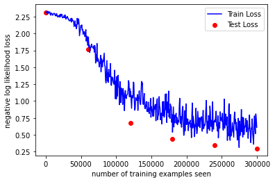

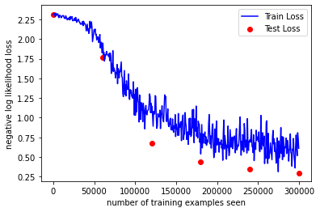

```python
fig = plt.figure()
plt.plot(train_counter, train_losses, color='blue')
plt.scatter(test_counter, test_losses, color='red')
plt.legend(['Train Loss', 'Test Loss'], loc='upper right')
plt.xlabel('number of training examples seen')
plt.ylabel('negative log likelihood loss')
fig
```

But before that let's again look at a few examples as we did earlier and compare the model's output.

```python
with torch.no_grad():
  output = network(example_data)
```

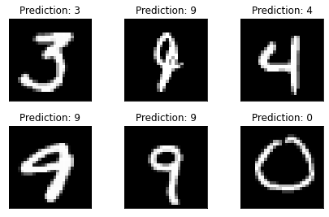

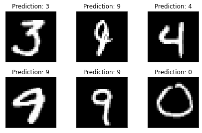

```python
fig = plt.figure()
for i in range(6):
  plt.subplot(2,3,i+1)
  plt.tight_layout()
  plt.imshow(example_data[i][0], cmap='gray', interpolation='none')
  plt.title("Prediction: {}".format(
    output.data.max(1, keepdim=True)[1][i].item()))
  plt.xticks([])
  plt.yticks([])
fig
```

Our model's predictions seem to be on point for those examples!

# Continued Training from Checkpoints

Now let's continue training the network, or rather see how we can continue training from the state_dicts we saved during our first training run. We'll initialize a new set of network and optimizers.

```python
continued_network = Net()
continued_optimizer = optim.SGD(network.parameters(), lr=learning_rate,
                                momentum=momentum)
```

Using `.load_state_dict()` we can now load the internal state of the network and optimizer when we last saved them.

```python
network_state_dict = torch.load("./results/model.pth")
continued_network.load_state_dict(network_state_dict)

optimizer_state_dict = torch.load("./results/optimizer.pth")
continued_optimizer.load_state_dict(optimizer_state_dict)
```

Again running a training loop should immediately pick up the training where we left it. To check on that let's simply use the same lists as before to keep track of the loss values. Due to the way we constructed the test counter for the number of training examples seen we manually have to append to it here.

```python
for i in range(6,9):
  test_counter.append(i*len(train_loader.dataset))
  train(i)
  test()
```

```
Train Epoch: 6 [0/60000 (0%)]	Loss: 0.619158
Train Epoch: 6 [640/60000 (1%)]	Loss: 0.609908
Train Epoch: 6 [1280/60000 (2%)]	Loss: 0.782651
Train Epoch: 6 [1920/60000 (3%)]	Loss: 0.473995
Train Epoch: 6 [2560/60000 (4%)]	Loss: 0.499595
Train Epoch: 6 [3200/60000 (5%)]	Loss: 0.602045
Train Epoch: 6 [3840/60000 (6%)]	Loss: 0.718961
Train Epoch: 6 [4480/60000 (7%)]	Loss: 0.642678
Train Epoch: 6 [5120/60000 (9%)]	Loss: 0.481905
Train Epoch: 6 [5760/60000 (10%)]	Loss: 0.478348
Train Epoch: 6 [6400/60000 (11%)]	Loss: 0.464366
Train Epoch: 6 [7040/60000 (12%)]	Loss: 0.486057
Train Epoch: 6 [7680/60000 (13%)]	Loss: 0.621143
Train Epoch: 6 [8320/60000 (14%)]	Loss: 0.502888
Train Epoch: 6 [8960/60000 (15%)]	Loss: 0.481229
Train Epoch: 6 [9600/60000 (16%)]	Loss: 0.507510
Train Epoch: 6 [10240/60000 (17%)]	Loss: 0.602757
Train Epoch: 6 [10880/60000 (18%)]	Loss: 0.602031
Train Epoch: 6 [11520/60000 (19%)]	Loss: 0.743317
Train Epoch: 6 [12160/60000 (20%)]	Loss: 0.599671
Train Epoch: 6 [12800/60000 (21%)]	Loss: 0.532802
Train Epoch: 6 [13440/60000 (22%)]	Loss: 0.535994
Train Epoch: 6 [14080/60000 (23%)]	Loss: 0.497214
Train Epoch: 6 [14720/60000 (25%)]	Loss: 0.476137
Train Epoch: 6 [15360/60000 (26%)]	Loss: 0.402692
Train Epoch: 6 [16000/60000 (27%)]	Loss: 0.565676
Train Epoch: 6 [16640/60000 (28%)]	Loss: 0.573583
Train Epoch: 6 [17280/60000 (29%)]	Loss: 0.561351
Train Epoch: 6 [17920/60000 (30%)]	Loss: 0.462769
Train Epoch: 6 [18560/60000 (31%)]	Loss: 0.718267
Train Epoch: 6 [19200/60000 (32%)]	Loss: 0.743555
Train Epoch: 6 [19840/60000 (33%)]	Loss: 0.614700
Train Epoch: 6 [20480/60000 (34%)]	Loss: 0.463140
Train Epoch: 6 [21120/60000 (35%)]	Loss: 0.688085
Train Epoch: 6 [21760/60000 (36%)]	Loss: 0.740881
Train Epoch: 6 [22400/60000 (37%)]	Loss: 0.721933
Train Epoch: 6 [23040/60000 (38%)]	Loss: 0.545263
Train Epoch: 6 [23680/60000 (39%)]	Loss: 0.476755
Train Epoch: 6 [24320/60000 (41%)]	Loss: 0.574884
Train Epoch: 6 [24960/60000 (42%)]	Loss: 0.389784
```

[output cut: 235 more lines]

```
Train Epoch: 8 [51840/60000 (86%)]	Loss: 0.558773
Train Epoch: 8 [52480/60000 (87%)]	Loss: 0.441931
Train Epoch: 8 [53120/60000 (88%)]	Loss: 0.448403
Train Epoch: 8 [53760/60000 (90%)]	Loss: 0.435961
Train Epoch: 8 [54400/60000 (91%)]	Loss: 0.554383
Train Epoch: 8 [55040/60000 (92%)]	Loss: 0.459826
Train Epoch: 8 [55680/60000 (93%)]	Loss: 0.523817
Train Epoch: 8 [56320/60000 (94%)]	Loss: 0.363053
Train Epoch: 8 [56960/60000 (95%)]	Loss: 0.415354
Train Epoch: 8 [57600/60000 (96%)]	Loss: 0.312471
Train Epoch: 8 [58240/60000 (97%)]	Loss: 0.452052
Train Epoch: 8 [58880/60000 (98%)]	Loss: 0.309831
Train Epoch: 8 [59520/60000 (99%)]	Loss: 0.748687

Test set: Avg. loss: 0.2072, Accuracy: 9388/10000 (94%)
```

Great! We again see a (much slower) increase in test set accuracy from epoch to epoch. Let's visualize this to further inspect the training progress.

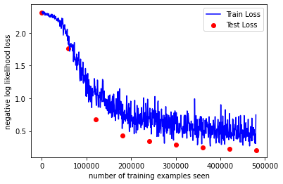

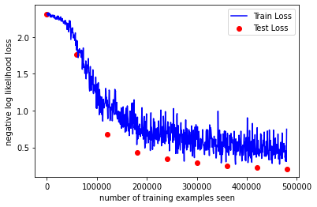

```python
fig = plt.figure()
plt.plot(train_counter, train_losses, color='blue')
plt.scatter(test_counter, test_losses, color='red')
plt.legend(['Train Loss', 'Test Loss'], loc='upper right')
plt.xlabel('number of training examples seen')
plt.ylabel('negative log likelihood loss')
fig
```

From this we can conclue two things:

2. We still don't seem to run into overfitting issues! It looks like our dropout layers did a good job regularizing the model.

In summary we built a new environment with PyTorch and TorchVision, used it to classifiy handwritten digits from the MNIST dataset and hopefully developed a good intuition using PyTorch. For further information the official [PyTorch documentation](https://pytorch.org/docs/stable/index.html) is really nicely written and the [forums](https://discuss.pytorch.org/) are also quite active!